# Exercícios da Lista 3

Aluno: Germano Andrade Brandão

19 Abril 2020

## Nota inicial

Para a resolução dos exercícios, foram utilizados os pacotes “ggplot2” (para construção de gráficos) e “ggpubr” (para alterar a organização os gráficos).

### Capítulo 3, Edição 2017: Ex 28 a 31

## Ex. 28

Para se estudar o desempenho de duas corretoras de ações, selecionou-se de cada uma delas, amostras aleatórias das ações negociadas. Para cada ação selecionada, computou-se a porcentagem de lucro apresentada durante um período fixado de tempo. Os dados estão a seguir:

```r
corretora.A <- data.frame(periodo_1 = c(45, 62, 38, 55, 54, 65),
                          periodo_2 = c(60, 55, 48, 56, 59, 55),
                          periodo_3 = c(54, 70, 64, 55, 48, 60))

corretora.A
```

```
##   periodo_1 periodo_2 periodo_3
## 1        45        60        54
## 2        62        55        70
## 3        38        48        64
## 4        55        56        55
## 5        54        59        48
## 6        65        55        60
```

```r
corretora.B <- data.frame(periodo_1 = c(57, 50, 59, 61, 57, 55, 59),
                          periodo_2 = c(55, 52, 55, 52, 57, 58, 51),
                          periodo_3 = c(58, 59, 56, 53, 50, 54, 56))

corretora.B
```

```
##   periodo_1 periodo_2 periodo_3
## 1        57        55        58
## 2        50        52        59
## 3        59        55        56
## 4        61        52        53
## 5        57        57        50
## 6        55        58        54
## 7        59        51        56
```

Que tipo de informação revelam esses dados? (Sugestão: Observar os quantis empíricos)

**Corretora A**: Percebemos, a partir de $q_2 -x_1$,$x_n - q_2$, $q_2 - q_1$ e $q_3 - q_2$, que os dados das porcentagens das ações da corretora A não são totalmente distribuídos simetricamente.

```r
Dados_Corret_A <-c(min(corretora.A),
                   quantile(c(corretora.A$periodo_1,
                              corretora.A$periodo_2,
                              corretora.A$periodo_3),
                            probs = c(0.25, 0.5, 0.75)),
                   max(corretora.A))

Dados_Corret_A_M <- matrix(Dados_Corret_A,
                           nrow = 1,
                           ncol = 5,
                           dimnames = list("A",
                                           c("x1", "q1", "q2", "q3", "xn")))
Dados_Corret_A_M
```

```
##   x1 q1 q2 q3 xn
## A 38 54 55 60 70
```

$q_2 -x_1$ $≅$ $x_n - q_2$

```r
#q2 - x1
Dados_Corret_A_M[, "q2"] - Dados_Corret_A_M[,"x1"]
```

```
## [1] 17
```

```r
#xn - q2
Dados_Corret_A_M[, "xn"] - Dados_Corret_A_M[, "q2"]
```

```
## [1] 15
```

$q_2 - q_1$ $≠$ $q_3 - q_2$

```r
#q2 - q1
Dados_Corret_A_M[, "q2"] - Dados_Corret_A_M[,"q1"]
```

```
## [1] 1
```

```r
#q3 - q2
Dados_Corret_A_M[, "q3"] - Dados_Corret_A_M[, "q2"]
```

```
## [1] 5
```

**Corretora B**: Já na corretora B, percebemos, a partir de $q_2 -x_1$,$x_n - q_2$, $q_2 - q_1$ e $q_3 - q_2$, que os dados das porcentagens das ações são distribuídos de uma forma mais homogênea.

```r
Dados_Corret_B <-c(min(corretora.B),
                   quantile(c(corretora.B$periodo_1,
                              corretora.B$periodo_2,
                              corretora.B$periodo_3),
                            probs = c(0.25, 0.5, 0.75)),
                   max(corretora.B))

Dados_Corret_B_M <- matrix(Dados_Corret_B,
                           nrow = 1,
                           ncol = 5,
                           dimnames = list("A",
                                           c("x1", "q1", "q2", "q3", "xn")))

#Esquema dos cinco números
Dados_Corret_B_M
```

```
##   x1 q1 q2 q3 xn
## A 50 53 56 58 61
```

$q_2 -x_1$ $≅$ $x_n - q_2$

```r
#q2 - x1
Dados_Corret_B_M[, "q2"] - Dados_Corret_B_M[,"x1"]
```

```
## [1] 6
```

```r
#xn - q2
Dados_Corret_B_M[, "xn"] - Dados_Corret_B_M[, "q2"]
```

```
## [1] 5
```

$q_2 - q_1$ $≅$ $q_3 - q_2$

```r
#q2 - q1
Dados_Corret_B_M[, "q2"] - Dados_Corret_B_M[,"q1"]
```

```
## [1] 3
```

```r
#q3 - q2
Dados_Corret_B_M[, "q3"] - Dados_Corret_B_M[, "q2"]
```

```
## [1] 2
```

## Ex. 29

Para verificar a homogeneidade das duas populações do problema anterior, um estatístico sugeriu que se usasse o quociente
$$F = \frac{var(X/A)}{var(X/B)}$$
sendo $var(X/A)$ a variância de X para a corretora A; $X =$ porcentagem de lucro. No entanto, o profissional não disse qual decisão tomar baseado nesse valor. Que regra de decisão voce adotaria para dizer se são homogêneas ou não?

**Faça sua análise aqui**

```r
# Resposta
```

- Caso $var(X/A)$ seja $maior$ que $var(X/B)$, o número $F$ será maior que $1$ e tão maior quanto a proporção da diferença entre as duas.
- Já se $var(X/B)$ for $maior$ que $var(X/A)$, o número $F$ será menor que $1$ e quanto maior a diferença entre as duas, mais perto de $0$ será o quociente.
- E, por fim, caso as variâncias sejam homogêneas, $F = 1$ ou $F$ muito próximo a $1$.

## Ex. 30

Faça um gráfico *boxplot* para cada uma das corretoras e compare os dois conjuntos de dados a partir dos gráficos.

**Escreva sua resposta aqui**

```r
C_A <- ggplot(data = data.frame(c(corretora.A$periodo_1,
                                  corretora.A$periodo_2,
                                  corretora.A$periodo_3)),
              aes(y = c(corretora.A$periodo_1,
                        corretora.A$periodo_2,
                        corretora.A$periodo_3))) +
  geom_boxplot(fill = "seagreen1",
               outlier.shape = 8,
               outlier.colour = "red",
               outlier.size = 2) +
  scale_x_continuous(b = NULL) +
  theme_classic() +
  labs(title = "Box Plot Corretora A",
       y = "% das ações") +
  scale_y_continuous(breaks = c(38, 54, 55, 60, 70))
```

```r
C_B <- ggplot(data = data.frame(c(corretora.B$periodo_1,
                                  corretora.B$periodo_2,
                                  corretora.B$periodo_3)),
              aes(y = c(corretora.B$periodo_1,
                        corretora.B$periodo_2,
                        corretora.B$periodo_3))) +
  geom_boxplot(fill = "hotpink1") +
  scale_x_continuous(b = NULL) +
  theme_classic() +
  labs(title = "Box Plot Corretora B",
       y = "% das ações") +
  scale_y_continuous(breaks = c(50, 53, 56, 58, 61))
```

Podemos perceber novamente que os dados têm uma variação assimétrica na corretora A e, já na B, a distribuição em torno da mediana é mais normal.

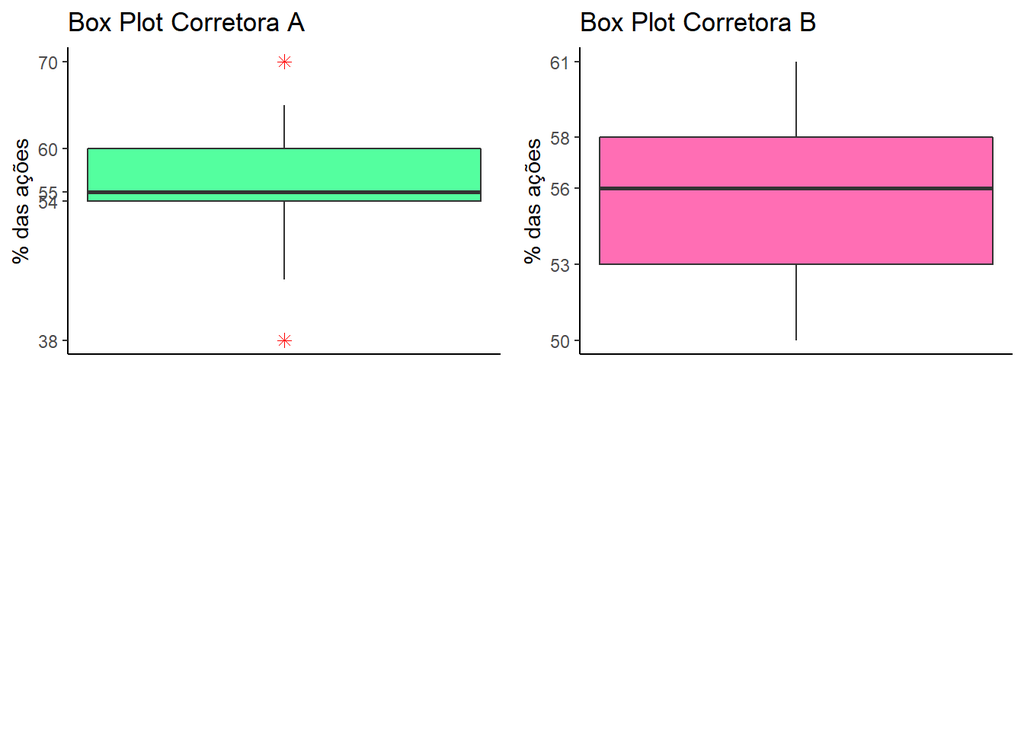

```r
ggarrange(C_A, C_B,
          ncol = 2, nrow = 2)
```

## Ex. 31

Para decidir se o desempenho das duas corretoras são semelhantes ou não, adotou-se o seguinte teste:

$$t = \frac{\bar{x_A} - \bar{x_B}}{S^2*\sqrt{1/{n_A} - 1/{n_B}}}$$

$$S^2 = \frac{(n_A -1)var(X/A) + (n_B -1)var(X/B)}{n_A + n_B - 2}$$
Sendo $n_A$ e $n_B$ o número de ações selecionadas das corretoras $A$ e $B$ respectivamente.

Caso $|t| < 2$, os desempenhos são semelhantes, caso contrário, são diferentes. Qual seria a sua conclusão?

**Escreva sua resposta aqui**

- Como chegamos ao resultado de $|t| = 0.1014008$, concluímos de que o desempenho das duas corretoras são semelhantes.

```r
#Organizando os dados da corretora A em um único vetor:
Corret_A <- c(corretora.A$periodo_1,
              corretora.A$periodo_2,
              corretora.A$periodo_3)

Corret_A
```

```
##  [1] 45 62 38 55 54 65 60 55 48 56 59 55 54 70 64 55 48 60
```

```r
#Organizando os dados da corretora B em um único vetor:
Corret_B <- c(corretora.B$periodo_1,
              corretora.B$periodo_2,
              corretora.B$periodo_3)
Corret_B
```

```
##  [1] 57 50 59 61 57 55 59 55 52 55 52 57 58 51 58 59 56 53 50 54 56
```

```r
n_A <- length(Corret_A)
n_B <- length(Corret_B)

media_A <- mean(Corret_A)
media_B <- mean(Corret_B)

var_A <- var(Corret_A)
var_B <- var(Corret_B)

#Cálculo do "S^2"
S_2 <-((n_A -1)*var_A + (n_B - 1)*var_B)/(n_A + n_B - 2)

#Cálculo do "t"
t <- (media_A - media_B)/(S_2*((1/n_A) - (1/n_B))^(1/2))

#módulo de "t" igual a:
abs(t)
```

```
## [1] 0.1014008
```